# Capstone Data Wrangle 01

Tom Thorpe

March 28, 2018

## Objective

Initial data cleanup of capstone project forest coverage data set.

Include required libraries.

```r
library(dplyr)
```

Point to data.

```r
#infile="C:/Users/Tom/git/datasciencefoundation/ForestCoverage/forestcover.csv"
infile="C:/Users/Tom/git/datasciencefoundation/ForestCoverage/forestsmall.csv"
transformfile="C:/Users/Tom/git/datasciencefoundation/ForestCoverage/AlternateCoding01.csv"
outfile="C:/Users/Tom/git/datasciencefoundation/ForestCoverage/forestcover_clean.csv"
```

Load the data.

```r
forestcover <- read.csv(infile,header=TRUE,sep=",") %>% tbl_df()
xform <- read.csv(transformfile,header=TRUE,sep=",") %>% tbl_df()
```

## Quick peek at the data

```r
glimpse(forestcover)
```

```
## Observations: 501
## Variables: 55
## $ Elev.m         <int> 2596, 2590, 2804, 2785, 2595, 2579, 2606, 2605,...
## $ Aspect.deg     <int> 51, 56, 139, 155, 45, 132, 45, 49, 45, 59, 201,...
## $ Slope.deg      <int> 3, 2, 9, 18, 2, 6, 7, 4, 9, 10, 4, 11, 22, 7, 4...
## $ H2O_HD.m       <int> 258, 212, 268, 242, 153, 300, 270, 234, 240, 24...
## $ H2O_VD.m       <int> 0, -6, 65, 118, -1, -15, 5, 7, 56, 11, 51, 26, ...
## $ Road_HD.m      <int> 510, 390, 3180, 3090, 391, 67, 633, 573, 666, 6...
## $ Shade_9AM.255  <int> 221, 220, 234, 238, 220, 230, 222, 222, 223, 22...
## $ Shade_12PM.255 <int> 232, 235, 238, 238, 234, 237, 225, 230, 221, 21...
## $ Shade_3PM.255  <int> 148, 151, 135, 122, 150, 140, 138, 144, 133, 12...
## $ FirePt_HD.m    <int> 6279, 6225, 6121, 6211, 6172, 6031, 6256, 6228,...
## $ RW_Wild        <int> 1, 1, 1, 1, 1, 1, 1, 1, 1, 1, 1, 1, 1, 1, 1, 1,...
## $ NE_Wild        <int> 0, 0, 0, 0, 0, 0, 0, 0, 0, 0, 0, 0, 0, 0, 0, 0,...
## $ CM_Wild        <int> 0, 0, 0, 0, 0, 0, 0, 0, 0, 0, 0, 0, 0, 0, 0, 0,...
```

[output cut: 42 more lines]

```r
forestcover
```

```
## # A tibble: 501 x 55
##    Elev.m Aspect.deg Slope.deg H2O_HD.m H2O_VD.m Road_HD.m Shade_9AM.255
##     <int>      <int>     <int>    <int>    <int>     <int>         <int>
##  1   2596         51         3      258        0       510           221
##  2   2590         56         2      212       -6       390           220
##  3   2804        139         9      268       65      3180           234
##  4   2785        155        18      242      118      3090           238
##  5   2595         45         2      153       -1       391           220
##  6   2579        132         6      300      -15        67           230
##  7   2606         45         7      270        5       633           222
##  8   2605         49         4      234        7       573           222
##  9   2617         45         9      240       56       666           223
## 10   2612         59        10      247       11       636           228
## # ... with 491 more rows, and 48 more variables: Shade_12PM.255 <int>,
## #   Shade_3PM.255 <int>, FirePt_HD.m <int>, RW_Wild <int>, NE_Wild <int>,
## #   CM_Wild <int>, CP_Wild <int>, ST01 <int>, ST02 <int>, ST03 <int>,
## #   ST04 <int>, ST05 <int>, ST06 <int>, ST07 <int>, ST08 <int>,
## #   ST09 <int>, ST10 <int>, ST11 <int>, ST12 <int>, ST13 <int>,
## #   ST14 <int>, ST15 <int>, ST16 <int>, ST17 <int>, ST18 <int>,
## #   ST19 <int>, ST20 <int>, ST21 <int>, ST22 <int>, ST23 <int>,
## #   ST24 <int>, ST25 <int>, ST26 <int>, ST27 <int>, ST28 <int>,
## #   ST29 <int>, ST30 <int>, ST31 <int>, ST32 <int>, ST33 <int>,
## #   ST34 <int>, ST35 <int>, ST36 <int>, ST37 <int>, ST38 <int>,
## #   ST39 <int>, ST40 <int>, CovType <int>
```

```r
#apply(forestcover,2,table)
glimpse(xform)
```

```
## Observations: 40
## Variables: 62
## $ ST                      <int> 36, 11, 10, 13, 32, 1, 29, 30, 16, 34,...
## $ USFS_Code               <int> 8707, 4704, 4703, 4758, 7756, 2702, 77...
## $ Description             <fct> Bross family - Rock land - Cryumbrepts...
## $ Montane_low             <int> NA, NA, NA, NA, NA, 1, NA, NA, NA, NA,...
## $ Montane                 <int> NA, 1, 1, 1, NA, NA, NA, NA, 1, NA, NA...
## $ Subalpine               <int> NA, NA, NA, NA, 1, NA, 1, 1, 1, 1, NA,...
## $ Alpine                  <int> 1, NA, NA, NA, NA, NA, NA, NA, NA, NA,...
## $ Dry                     <int> NA, NA, NA, NA, NA, NA, NA, NA, NA, NA...
## $ Non_Dry                 <int> NA, 1, 1, 1, NA, 1, NA, NA, 1, NA, NA,...
## $ Alluviam                <int> NA, NA, NA, NA, NA, NA, NA, NA, 1, NA,...
## $ Glacial                 <int> NA, NA, NA, NA, NA, NA, NA, NA, NA, NA...
## $ Sed_mix                 <int> NA, NA, NA, NA, NA, NA, NA, NA, NA, NA...
## $ Ign_Meta                <int> 1, 1, 1, 1, 1, 1, 1, 1, NA, 1, 1, NA, ...
```

[output cut: 49 more lines]

```r
xform
```

```
## # A tibble: 40 x 62
##       ST USFS_Code Description  Montane_low Montane Subalpine Alpine   Dry
##    <int>     <int> <fct>              <int>   <int>     <int>  <int> <int>
##  1    36      8707 Bross famil~          NA      NA        NA      1    NA
##  2    11      4704 Bullwark - ~          NA       1        NA     NA    NA
##  3    10      4703 Bullwark - ~          NA       1        NA     NA    NA
##  4    13      4758 Catamount f~          NA       1        NA     NA    NA
##  5    32      7756 Catamount f~          NA      NA         1     NA    NA
##  6     1      2702 Cathedral f~           1      NA        NA     NA    NA
##  7    29      7745 Como - Lega~          NA      NA         1     NA    NA
##  8    30      7746 Como family~          NA      NA         1     NA    NA
##  9    16      6101 Cryaquolls ~          NA       1         1     NA    NA
## 10    34      7790 Cryorthents~          NA      NA         1     NA    NA
## # ... with 30 more rows, and 54 more variables: Non_Dry <int>,
## #   Alluviam <int>, Glacial <int>, Sed_mix <int>, Ign_Meta <int>,
## #   Aquolis_cmplx <int>, Argiborolis_Pachic <int>,
## #   Borohemists_cmplx <int>, Bross <int>, Bullwark <int>,
## #   Bullwark_Cmplx <int>, Catamount <int>, Catamount_cmplx <int>,
## #   Cathedral <int>, Como <int>, Cryaquepts_cmplx <int>,
## #   Cryaquepts_Typic <int>, Cryaquolls <int>, Cryaquolls_cmplx <int>,
## #   Cryaquolls_Typic <int>, Cryaquolls_Typic_cmplx <int>,
## #   Cryoborolis_cmplx <int>, Cryorthents <int>, Cryorthents_cmplx <int>,
## #   Cryumbrepts <int>, Cryumbrepts_cmplx <int>, Gateview <int>,
## #   Gothic <int>, Granile <int>, Haploborolis <int>, Legault <int>,
## #   Legault_cmplx <int>, Leighcan <int>, Leighcan_cmplx <int>,
## #   Leighcan_warm <int>, Moran <int>, Ratake <int>, Ratake_cmplx <int>,
## #   Rogert <int>, Supervisor_Limber_cmplx <int>, Troutville <int>,
## #   Unspecified <int>, Vanet <int>, Wetmore <int>, Bouldery_ext <int>,
## #   Rock_Land <int>, Rock_Land_cmplx <int>, Rock_Outcrop <int>,
## #   Rock_Outcrop_cmplx <int>, Rubbly <int>, Stony <int>,
## #   Stony_extreme <int>, Stony_very <int>, Till_Substratum <int>
```

## Expand Soil type

The soil type needs to be expanded into columns that comprise the different components of each soil type. A particular soil type represents the climate zone, geologic zone, one or more soil families and one or more rock densities for a given sample/row.

The xform data set drives the conversion of soil type to additional columns noted above. Each row in the xform data set corresponds to one of the 40 possible soil types in the forest coverage data set. The first 3 columns identify the soil type number that corresponds to the soil type column in the forest coverage data set, a US Forest Service soil code and a description of the soil families and rock densities for the soil type. The remaining columns are the columns that will be added to the forest coverage data set and the values for each column.

I created the xform data set to reflect what I think would be a good way to break out the soil type. I may want to change the way the data is broken out and therefore want later changes to data encoding to be easier by using the xform data set to be the source of column names and values with minimum hard coding involved.

The xform dataset is sorted by ST, the soil type column, so that it can be indexed by the soil type index that will be calculated in the forest coverage data set.

```r
xform<-arrange(xform,ST)
xform
```

```
## # A tibble: 40 x 62
##       ST USFS_Code Description  Montane_low Montane Subalpine Alpine   Dry
##    <int>     <int> <fct>              <int>   <int>     <int>  <int> <int>
##  1     1      2702 Cathedral f~           1      NA        NA     NA    NA
##  2     2      2703 Vanet - Rat~           1      NA        NA     NA    NA
##  3     3      2704 Haploboroli~           1      NA        NA     NA    NA
##  4     4      2705 Ratake fami~           1      NA        NA     NA    NA
##  5     5      2706 Vanet famil~           1      NA        NA     NA    NA
##  6     6      2717 Vanet - Wet~           1      NA        NA     NA    NA
##  7     7      3501 Gothic fami~          NA       1        NA     NA     1
##  8     8      3502 Supervisor ~          NA       1        NA     NA     1
##  9     9      4201 Troutville ~          NA       1        NA     NA    NA
## 10    10      4703 Bullwark - ~          NA       1        NA     NA    NA
## # ... with 30 more rows, and 54 more variables: Non_Dry <int>,
## #   Alluviam <int>, Glacial <int>, Sed_mix <int>, Ign_Meta <int>,
## #   Aquolis_cmplx <int>, Argiborolis_Pachic <int>,
## #   Borohemists_cmplx <int>, Bross <int>, Bullwark <int>,
## #   Bullwark_Cmplx <int>, Catamount <int>, Catamount_cmplx <int>,
## #   Cathedral <int>, Como <int>, Cryaquepts_cmplx <int>,
## #   Cryaquepts_Typic <int>, Cryaquolls <int>, Cryaquolls_cmplx <int>,
## #   Cryaquolls_Typic <int>, Cryaquolls_Typic_cmplx <int>,
## #   Cryoborolis_cmplx <int>, Cryorthents <int>, Cryorthents_cmplx <int>,
## #   Cryumbrepts <int>, Cryumbrepts_cmplx <int>, Gateview <int>,
## #   Gothic <int>, Granile <int>, Haploborolis <int>, Legault <int>,
## #   Legault_cmplx <int>, Leighcan <int>, Leighcan_cmplx <int>,
## #   Leighcan_warm <int>, Moran <int>, Ratake <int>, Ratake_cmplx <int>,
## #   Rogert <int>, Supervisor_Limber_cmplx <int>, Troutville <int>,
## #   Unspecified <int>, Vanet <int>, Wetmore <int>, Bouldery_ext <int>,
## #   Rock_Land <int>, Rock_Land_cmplx <int>, Rock_Outcrop <int>,
## #   Rock_Outcrop_cmplx <int>, Rubbly <int>, Stony <int>,
## #   Stony_extreme <int>, Stony_very <int>, Till_Substratum <int>
```

We want to add the same soil data column names in the xform data set to the forest coverage data set. Unfortunately I was not able to find a way to use a variable name to assign the name of the new column when using the *mutate()* function. We can use the *colnames* function to change the column name after each mutate operation adds a column to the forest coverage data set.

Create a new column to retain the soil type as a number.

```r
forestcover <- mutate(forestcover,soil_type = 0)
glimpse(forestcover)
```

```
## Observations: 501
## Variables: 56
## $ Elev.m         <int> 2596, 2590, 2804, 2785, 2595, 2579, 2606, 2605,...
## $ Aspect.deg     <int> 51, 56, 139, 155, 45, 132, 45, 49, 45, 59, 201,...
## $ Slope.deg      <int> 3, 2, 9, 18, 2, 6, 7, 4, 9, 10, 4, 11, 22, 7, 4...
## $ H2O_HD.m       <int> 258, 212, 268, 242, 153, 300, 270, 234, 240, 24...
## $ H2O_VD.m       <int> 0, -6, 65, 118, -1, -15, 5, 7, 56, 11, 51, 26, ...
## $ Road_HD.m      <int> 510, 390, 3180, 3090, 391, 67, 633, 573, 666, 6...
## $ Shade_9AM.255  <int> 221, 220, 234, 238, 220, 230, 222, 222, 223, 22...
## $ Shade_12PM.255 <int> 232, 235, 238, 238, 234, 237, 225, 230, 221, 21...
## $ Shade_3PM.255  <int> 148, 151, 135, 122, 150, 140, 138, 144, 133, 12...
## $ FirePt_HD.m    <int> 6279, 6225, 6121, 6211, 6172, 6031, 6256, 6228,...
## $ RW_Wild        <int> 1, 1, 1, 1, 1, 1, 1, 1, 1, 1, 1, 1, 1, 1, 1, 1,...
## $ NE_Wild        <int> 0, 0, 0, 0, 0, 0, 0, 0, 0, 0, 0, 0, 0, 0, 0, 0,...
## $ CM_Wild        <int> 0, 0, 0, 0, 0, 0, 0, 0, 0, 0, 0, 0, 0, 0, 0, 0,...
```

[output cut: 43 more lines]

Start by getting the current forest coverage column names and an empty vector to collect the xform data set column names.

```r
xformcnames=c()
forestcnames=colnames(forestcover)
```

Next iterate through the column names in the xform data set. The first three columns in the xform data set are not to be added to the coverage data set. These column names are skipped by checking for the column names as shown in the first *if* statement below. This is the only hard coding done and the only requirement of column names in the xform data set.

For every other xform data set column, a column is added to the forest coverage data set. The xform column name is added to the xform data set column names and the forest service column names vectors. After the column is added to the forest coverage data set, the forest service column names vector will be used to reset the new column name. The xform column name vector will be used later to index both the xform and forest coverage data sets when setting values in the forest coverage data set.

```r
startTime=Sys.time()
print(paste("Column name creation started at",startTime))
```

```
## [1] "Column name creation started at 2018-03-29 12:52:21"
```

```r
for(colname in colnames(xform)){
  if (colname!="ST" & colname !="USFS_Code" & colname != "Description")
  {
    #print(colname)
    forestcover <- mutate(forestcover,colname = 0) # add column named "colname" to forestcover
    forestcnames<-c(forestcnames,colname)          # add the actual column name to forest colnames vector
    colnames(forestcover) <- forestcnames          # set the forest cover column names
    xformcnames=c(xformcnames,colname)             # add the column name to xform column names vector
  }
}
endTime=Sys.time()
print(paste("Column name creation completed at",endTime))
```

```
## [1] "Column name creation completed at 2018-03-29 12:52:21"
```

```r
print(paste("Elapsed time=",round(endTime-startTime),"seconds."))
```

```
## [1] "Elapsed time= 0 seconds."
```

```r
print(xformcnames)
```

```
##  [1] "Montane_low"             "Montane"
##  [3] "Subalpine"               "Alpine"
##  [5] "Dry"                     "Non_Dry"
##  [7] "Alluviam"                "Glacial"
##  [9] "Sed_mix"                 "Ign_Meta"
## [11] "Aquolis_cmplx"           "Argiborolis_Pachic"
## [13] "Borohemists_cmplx"       "Bross"
## [15] "Bullwark"                "Bullwark_Cmplx"
## [17] "Catamount"               "Catamount_cmplx"
## [19] "Cathedral"               "Como"
## [21] "Cryaquepts_cmplx"        "Cryaquepts_Typic"
## [23] "Cryaquolls"              "Cryaquolls_cmplx"
## [25] "Cryaquolls_Typic"        "Cryaquolls_Typic_cmplx"
## [27] "Cryoborolis_cmplx"       "Cryorthents"
## [29] "Cryorthents_cmplx"       "Cryumbrepts"
## [31] "Cryumbrepts_cmplx"       "Gateview"
## [33] "Gothic"                  "Granile"
## [35] "Haploborolis"            "Legault"
## [37] "Legault_cmplx"           "Leighcan"
## [39] "Leighcan_cmplx"          "Leighcan_warm"
## [41] "Moran"                   "Ratake"
## [43] "Ratake_cmplx"            "Rogert"
## [45] "Supervisor_Limber_cmplx" "Troutville"
## [47] "Unspecified"             "Vanet"
## [49] "Wetmore"                 "Bouldery_ext"
## [51] "Rock_Land"               "Rock_Land_cmplx"
## [53] "Rock_Outcrop"            "Rock_Outcrop_cmplx"
## [55] "Rubbly"                  "Stony"
## [57] "Stony_extreme"           "Stony_very"
## [59] "Till_Substratum"
```

```r
glimpse(forestcover)
```

```
## Observations: 501
## Variables: 115
## $ Elev.m                  <int> 2596, 2590, 2804, 2785, 2595, 2579, 26...
## $ Aspect.deg              <int> 51, 56, 139, 155, 45, 132, 45, 49, 45,...
## $ Slope.deg               <int> 3, 2, 9, 18, 2, 6, 7, 4, 9, 10, 4, 11,...
## $ H2O_HD.m                <int> 258, 212, 268, 242, 153, 300, 270, 234...
## $ H2O_VD.m                <int> 0, -6, 65, 118, -1, -15, 5, 7, 56, 11,...
## $ Road_HD.m               <int> 510, 390, 3180, 3090, 391, 67, 633, 57...
## $ Shade_9AM.255           <int> 221, 220, 234, 238, 220, 230, 222, 222...
## $ Shade_12PM.255          <int> 232, 235, 238, 238, 234, 237, 225, 230...
## $ Shade_3PM.255           <int> 148, 151, 135, 122, 150, 140, 138, 144...
## $ FirePt_HD.m             <int> 6279, 6225, 6121, 6211, 6172, 6031, 62...
## $ RW_Wild                 <int> 1, 1, 1, 1, 1, 1, 1, 1, 1, 1, 1, 1, 1,...
## $ NE_Wild                 <int> 0, 0, 0, 0, 0, 0, 0, 0, 0, 0, 0, 0, 0,...
## $ CM_Wild                 <int> 0, 0, 0, 0, 0, 0, 0, 0, 0, 0, 0, 0, 0,...
```

[output cut: 102 more lines]

The new columns have been added to the forest coverage data set and the column values need to be populated based on the values in the xform data set.

First the column index of the first soil type in the forest coverage data set must found. The soil type columns are labeled “ST01”, “ST02”, …, “ST40”, all togther with no other data columns between them. A non-zero value in one of the columns indicates the soil type. Finding the column index with the non zero value and subtracting the index of “ST01” gives the row index into the xform data set. The soil data from the corresponding soil type in the xform data set are then copied to the forest coverage data set.

Find the location of the “ST01” column in the forest coverage data set. There are 40 soil types in the forest coverage data set, so the last column index is found by adding 39 to the index of the “ST01” column.

```r
firstIndex<-grep("^ST01$", colnames(forestcover))
lastIndex<-firstIndex+39
print(paste("first=",firstIndex,", last=",lastIndex))
```

```
## [1] "first= 15 , last= 54"
```

All the information needed to proceed with the data update is now ready. The code comments describe the details to update the forest coverage data set.

```r
startTime=Sys.time()
print(paste("Starting forest coverage conversion at",startTime))
```

```
## [1] "Starting forest coverage conversion at 2018-03-29 12:52:21"
```

```r
errorCnt<- 0
# go through every row in the forest coverage data set
for(i in 1:nrow(forestcover)) {
  # find Soil type in this row
  soilIndex<-0    # this is the index variable that will be used to find the data in the xform data set
  soilTypeCnt<-0  # error check var: There should be exactly 1 soil type in the forest cover data set

  # check each "ST__" column in the forest coverage data set for a "1" indicating the soil type
  for (j in firstIndex:lastIndex) { # the first and last indicies of the soil types were calculated above
    if(forestcover[i,j]==1) {       # checking if a soil type was found. If "1", we have found one
      soilIndex=j-firstIndex+1      # calculate the soil index to be used by the xform data set
      soilTypeCnt<-soilTypeCnt+1    # count how many soil types we find. Should only be one
    }
  }

  # do some error checking to be sure there are no errors in the forest coverage data set
  if(soilIndex==0) {
    print(paste("Soil type mising in row",i))
    errorCnt <- errorCnt + 1
  }
  if(soilTypeCnt > 1) {
    print(paste("Too many soil types in row",i))
    errorCnt <- errorCnt + 1
  }
  #print(paste("row:",i,"Elev=",forestcover[i,1]))

  if(soilIndex > 0){
    forestcover[i,"soil_type"] <- soilIndex # save the original soil type code

    # copy the soil type data from the xform data set to the forest coverage data set
    for (colname in xformcnames) {                          # use xform column names for indexing
      if (!is.na(xform[soilIndex,colname])) {               # don't copy NA values
        forestcover[i,colname] <- xform[soilIndex,colname]
        # current forest cover row get the soil data from the xform data set
      }
    }
  }
}
endTime=Sys.time()
print(paste("Forest coverage conversion completed at",endTime))
```

```
## [1] "Forest coverage conversion completed at 2018-03-29 12:52:48"
```

```r
print(paste("Elapsed time=",round(endTime-startTime),"seconds."))
```

```
## [1] "Elapsed time= 27 seconds."
```

```r
print(paste(errorCnt,"errors were found."))
```

```
## [1] "0 errors were found."
```

```r
glimpse(forestcover)
```

```
## Observations: 501
## Variables: 115
## $ Elev.m                  <int> 2596, 2590, 2804, 2785, 2595, 2579, 26...
## $ Aspect.deg              <int> 51, 56, 139, 155, 45, 132, 45, 49, 45,...
## $ Slope.deg               <int> 3, 2, 9, 18, 2, 6, 7, 4, 9, 10, 4, 11,...
## $ H2O_HD.m                <int> 258, 212, 268, 242, 153, 300, 270, 234...
## $ H2O_VD.m                <int> 0, -6, 65, 118, -1, -15, 5, 7, 56, 11,...
## $ Road_HD.m               <int> 510, 390, 3180, 3090, 391, 67, 633, 57...
## $ Shade_9AM.255           <int> 221, 220, 234, 238, 220, 230, 222, 222...
## $ Shade_12PM.255          <int> 232, 235, 238, 238, 234, 237, 225, 230...
## $ Shade_3PM.255           <int> 148, 151, 135, 122, 150, 140, 138, 144...
## $ FirePt_HD.m             <int> 6279, 6225, 6121, 6211, 6172, 6031, 62...
## $ RW_Wild                 <int> 1, 1, 1, 1, 1, 1, 1, 1, 1, 1, 1, 1, 1,...
## $ NE_Wild                 <int> 0, 0, 0, 0, 0, 0, 0, 0, 0, 0, 0, 0, 0,...
## $ CM_Wild                 <int> 0, 0, 0, 0, 0, 0, 0, 0, 0, 0, 0, 0, 0,...
```

[output cut: 102 more lines]

## Data Scaling

Some scaling of the data may be required but is unknown at this time, so only a note is made here to remember to update this section as needed.

## Expand CovType variable into binary columns.

Create the column names.

```r
forestcover <- mutate(forestcover,Tree.Spruce.Fir=0)
forestcover <- mutate(forestcover,Tree.LodgepolePine=0)
forestcover <- mutate(forestcover,Tree.PonderosaPine=0)
forestcover <- mutate(forestcover,Tree.Cottonwood.Willow=0)
forestcover <- mutate(forestcover,Tree.Aspen=0)
forestcover <- mutate(forestcover,Tree.DouglasFir=0)
forestcover <- mutate(forestcover,Tree.Krummholz=0)
```

Populate the columns.

```r
forestcover$Tree.Spruce.Fir[forestcover$CovType == 1] <- 1
forestcover$Tree.LodgepolePine[forestcover$CovType == 2] <- 1
forestcover$Tree.PonderosaPine[forestcover$CovType == 3] <- 1
forestcover$Tree.Cottonwood.Willow[forestcover$CovType == 4] <- 1
forestcover$Tree.Aspen[forestcover$CovType == 5] <- 1
forestcover$Tree.DouglasFir[forestcover$CovType == 6] <- 1
forestcover$Tree.Krummholz[forestcover$CovType == 7] <- 1
glimpse(forestcover)
```

```
## Observations: 501
## Variables: 122
## $ Elev.m                  <int> 2596, 2590, 2804, 2785, 2595, 2579, 26...
## $ Aspect.deg              <int> 51, 56, 139, 155, 45, 132, 45, 49, 45,...
## $ Slope.deg               <int> 3, 2, 9, 18, 2, 6, 7, 4, 9, 10, 4, 11,...
## $ H2O_HD.m                <int> 258, 212, 268, 242, 153, 300, 270, 234...
## $ H2O_VD.m                <int> 0, -6, 65, 118, -1, -15, 5, 7, 56, 11,...
## $ Road_HD.m               <int> 510, 390, 3180, 3090, 391, 67, 633, 57...
## $ Shade_9AM.255           <int> 221, 220, 234, 238, 220, 230, 222, 222...
## $ Shade_12PM.255          <int> 232, 235, 238, 238, 234, 237, 225, 230...
## $ Shade_3PM.255           <int> 148, 151, 135, 122, 150, 140, 138, 144...
## $ FirePt_HD.m             <int> 6279, 6225, 6121, 6211, 6172, 6031, 62...
## $ RW_Wild                 <int> 1, 1, 1, 1, 1, 1, 1, 1, 1, 1, 1, 1, 1,...
## $ NE_Wild                 <int> 0, 0, 0, 0, 0, 0, 0, 0, 0, 0, 0, 0, 0,...
## $ CM_Wild                 <int> 0, 0, 0, 0, 0, 0, 0, 0, 0, 0, 0, 0, 0,...
```

[output cut: 109 more lines]

```r
table(forestcover$CovType)
```

```
##
##   1   2   5
## 138 283  80
```

```r
table(forestcover$Tree.Spruce.Fir)
```

```
##
##   0   1
## 363 138
```

```r
table(forestcover$Tree.LodgepolePine)
```

```
##
##   0   1
## 218 283
```

```r
table(forestcover$Tree.PonderosaPine)
```

```
##
##   0
## 501
```

```r
table(forestcover$Tree.Cottonwood.Willow)
```

```
##
##   0
## 501
```

```r
table(forestcover$Tree.Aspen)
```

```
##
##   0   1
## 421  80
```

```r
table(forestcover$Tree.DouglasFir)
```

```
##
##   0
## 501
```

```r
table(forestcover$Tree.Krummholz)
```

```
##
##   0
## 501
```

## Remove Unneeded columns

The binary soil type columns are no longer needed and are removed.

```r
startTime=Sys.time()
print(paste("Forest coverage column deletion started at",startTime))
```

```
## [1] "Forest coverage column deletion started at 2018-03-29 12:52:48"
```

```r
forestcover <- forestcover %>% select(-ST01,-ST02,-ST03,-ST04,-ST05,-ST06,-ST07,-ST08,-ST09,-ST10,
                                      -ST11,-ST12,-ST13,-ST14,-ST15,-ST16,-ST17,-ST18,-ST19,-ST20,
                                      -ST21,-ST22,-ST23,-ST24,-ST25,-ST26,-ST27,-ST28,-ST29,-ST30,
                                      -ST31,-ST32,-ST33,-ST34,-ST35,-ST36,-ST37,-ST38,-ST39,-ST40
                                      )
endTime=Sys.time()
print(paste("Forest coverage column deletion completed at",endTime))
```

```
## [1] "Forest coverage column deletion completed at 2018-03-29 12:52:48"
```

```r
print(paste("Elapsed time=",round(endTime-startTime),"seconds."))
```

```
## [1] "Elapsed time= 0 seconds."
```

```r
glimpse(forestcover)
```

```
## Observations: 501
## Variables: 82
## $ Elev.m                  <int> 2596, 2590, 2804, 2785, 2595, 2579, 26...
## $ Aspect.deg              <int> 51, 56, 139, 155, 45, 132, 45, 49, 45,...
## $ Slope.deg               <int> 3, 2, 9, 18, 2, 6, 7, 4, 9, 10, 4, 11,...
## $ H2O_HD.m                <int> 258, 212, 268, 242, 153, 300, 270, 234...
## $ H2O_VD.m                <int> 0, -6, 65, 118, -1, -15, 5, 7, 56, 11,...
## $ Road_HD.m               <int> 510, 390, 3180, 3090, 391, 67, 633, 57...
## $ Shade_9AM.255           <int> 221, 220, 234, 238, 220, 230, 222, 222...
## $ Shade_12PM.255          <int> 232, 235, 238, 238, 234, 237, 225, 230...
## $ Shade_3PM.255           <int> 148, 151, 135, 122, 150, 140, 138, 144...
## $ FirePt_HD.m             <int> 6279, 6225, 6121, 6211, 6172, 6031, 62...
## $ RW_Wild                 <int> 1, 1, 1, 1, 1, 1, 1, 1, 1, 1, 1, 1, 1,...
## $ NE_Wild                 <int> 0, 0, 0, 0, 0, 0, 0, 0, 0, 0, 0, 0, 0,...
## $ CM_Wild                 <int> 0, 0, 0, 0, 0, 0, 0, 0, 0, 0, 0, 0, 0,...
```

[output cut: 69 more lines]

Save the cleaned data in a CSV file.

```r
write.csv(forestcover, file=outfile,row.names=FALSE)
```

## Data distributions

Now check some data distributions.

```
## [1] "Plot creation started at 2018-03-29 12:52:48"
```

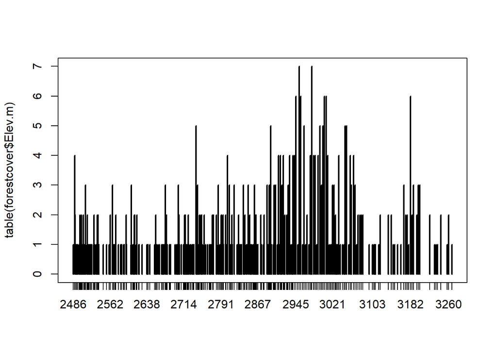

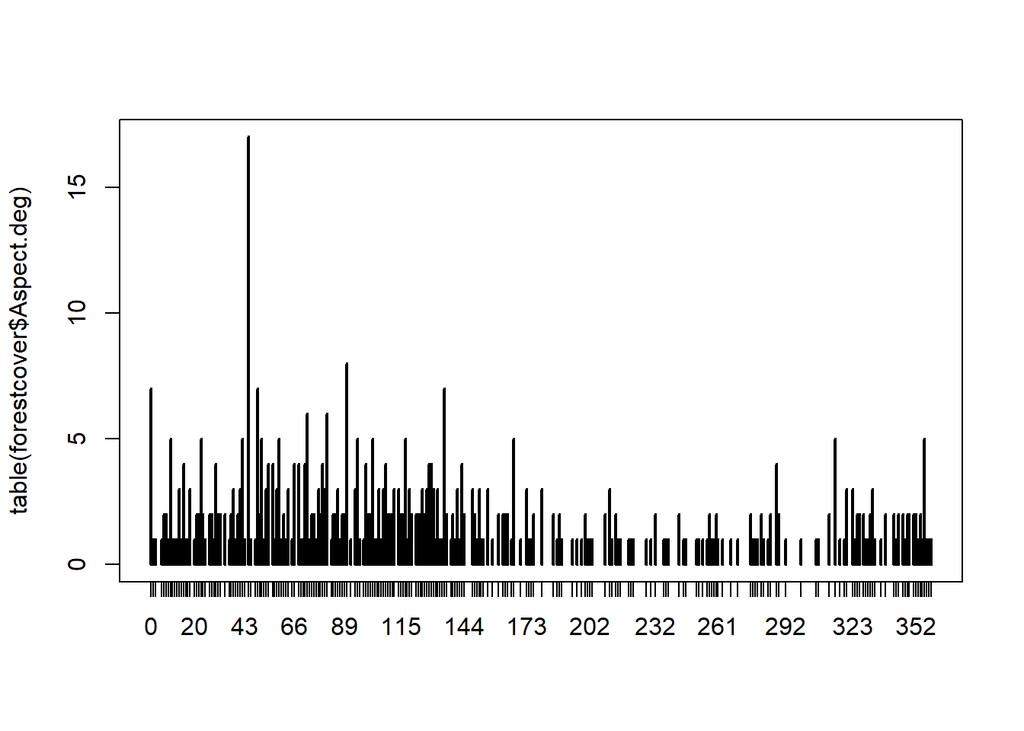

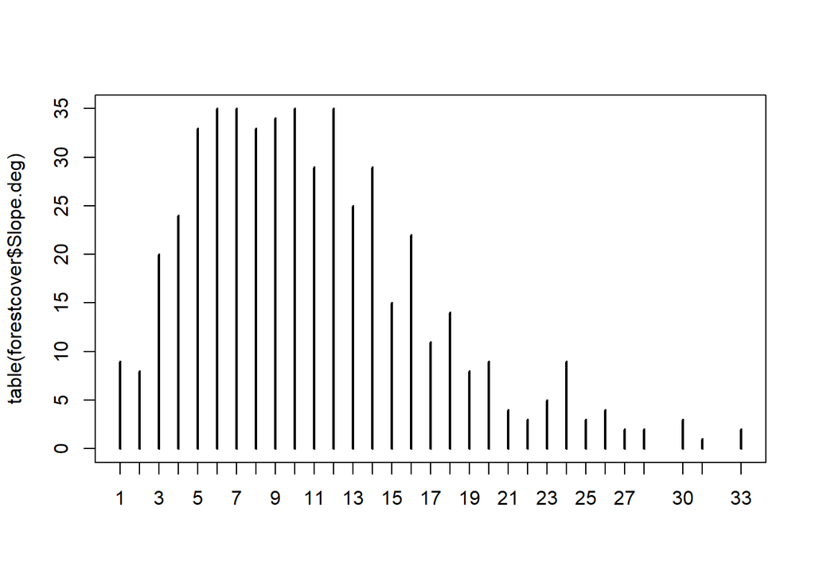

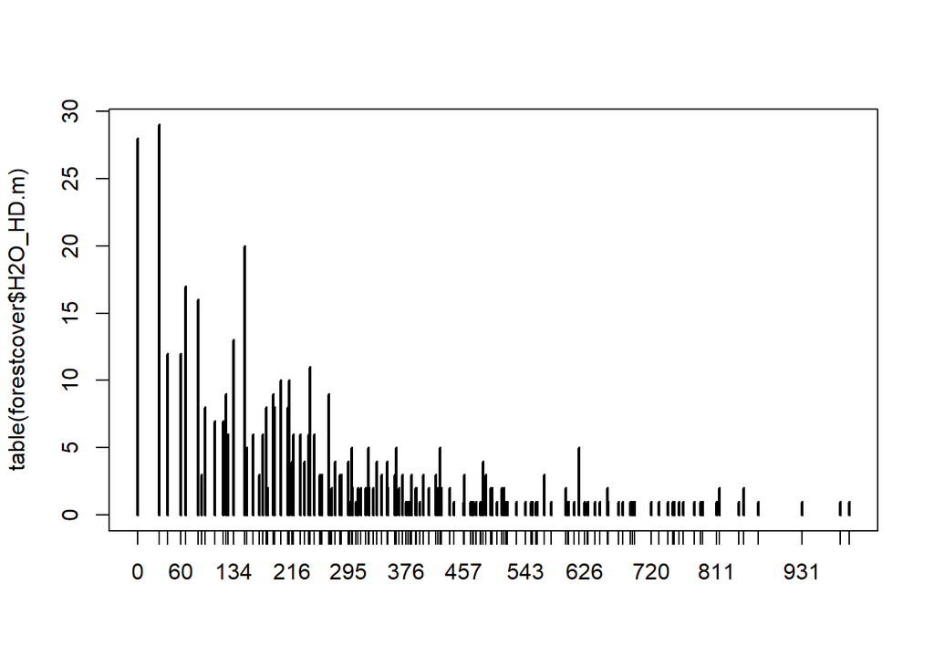

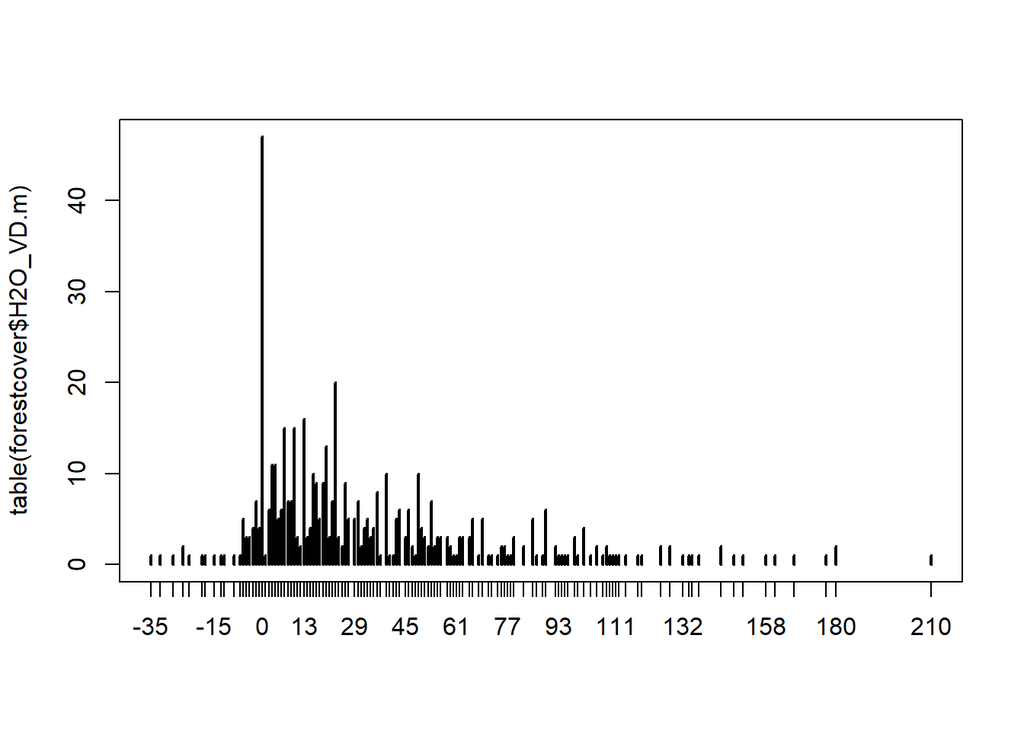

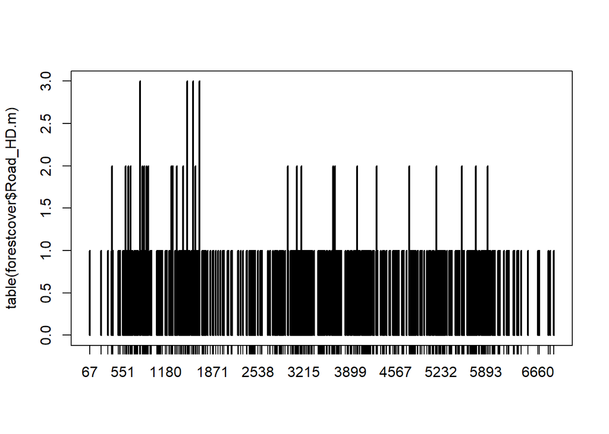

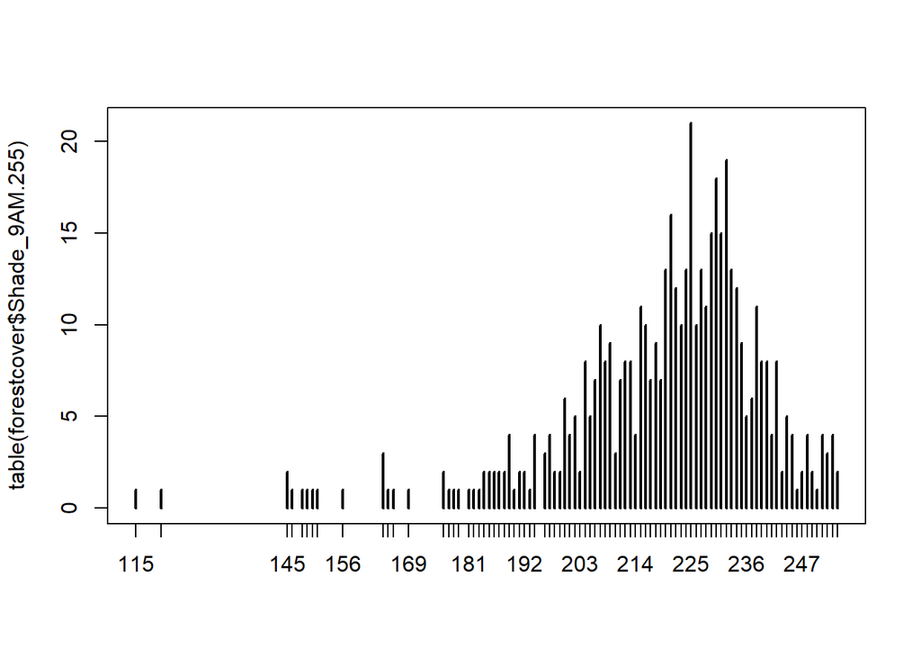

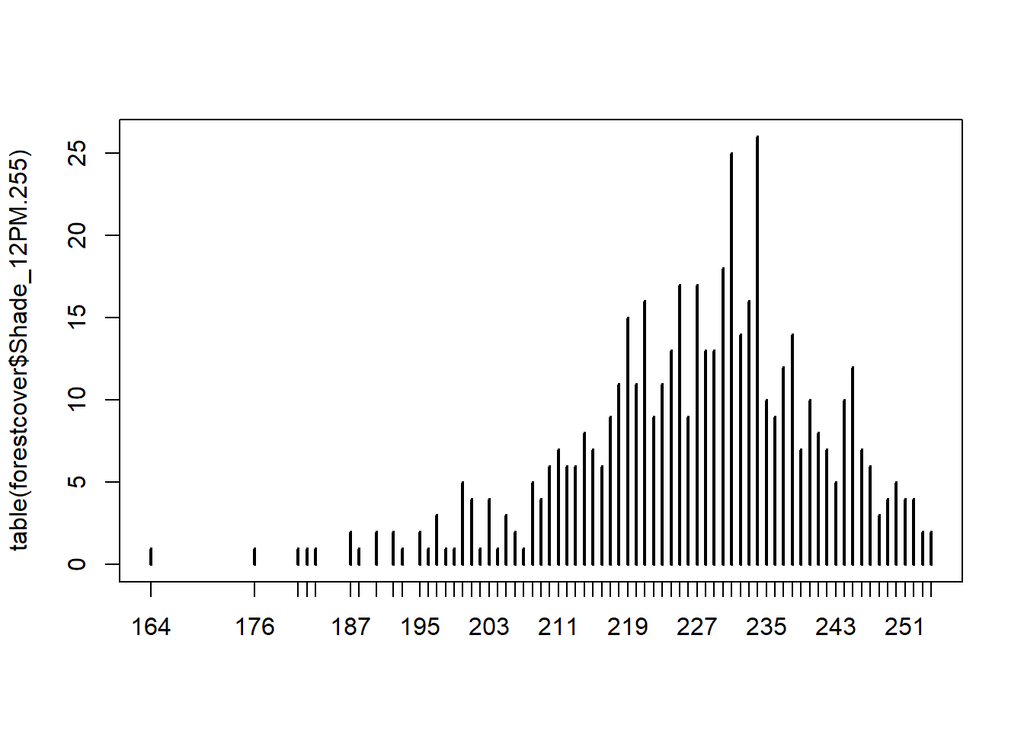

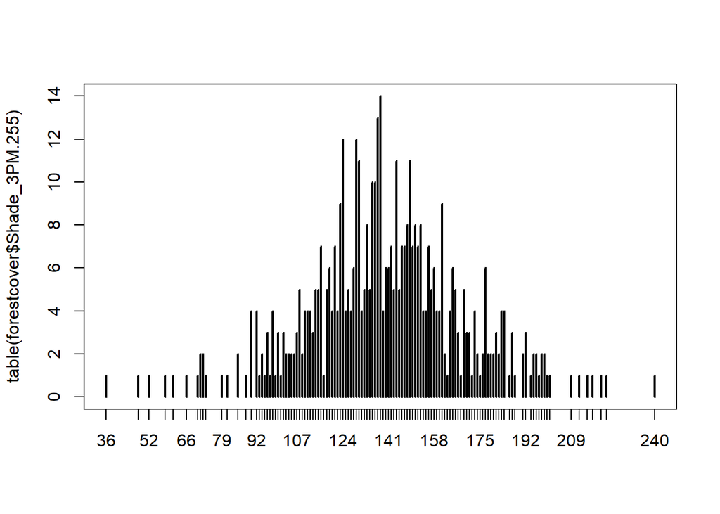

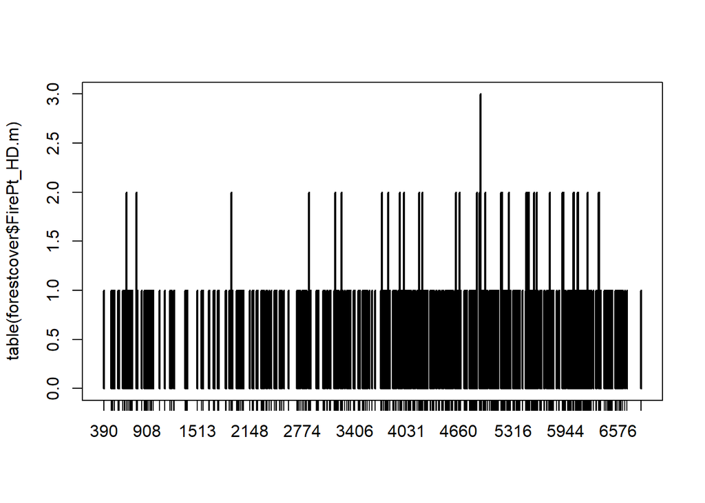

```
## [1] "Plots completed at 2018-03-29 12:52:49"
## [1] "Elapsed time= 1 seconds."
```

```r
#apply(xform,2,table)
test=TRUE
if(test) {
  startTime=Sys.time()
  print(paste("Plot creation started at",startTime))

  plot(table(forestcover$Elev.m))
  plot(table(forestcover$Aspect.deg))
  plot(table(forestcover$Slope.deg))
  plot(table(forestcover$H2O_HD.m))
  plot(table(forestcover$H2O_VD.m))
  plot(table(forestcover$Road_HD.m))
  plot(table(forestcover$Shade_9AM.255))
  plot(table(forestcover$Shade_12PM.255))
  plot(table(forestcover$Shade_3PM.255))
  plot(table(forestcover$FirePt_HD.m))

  endTime=Sys.time()
  print(paste("Plots completed at",endTime))
  print(paste("Elapsed time=",round(endTime-startTime),"seconds."))

}
```

That concludes the current data wrangling exercise on my capstone data.